FJ

# Feidhelm Joyce

Business & Data Analyst  
Boston, MA

linkedin.com/in/feidhelmjoyce  
github.com/FeidhelmJ

MARKETING ANALYTICS

## Classification Models

← Back to Marketing Analytics

```
import numpy as np
import pandas as pd
import matplotlib.pyplot as plt
import seaborn as sns
from sklearn.model_selection import train_test_split
from sklearn.linear_model import LogisticRegression
from sklearn.metrics import accuracy_score
from sklearn.metrics import confusion_matrix
```

**Part I: Logistic Regression Model**

A.

Bring the dataset lobsterland_passholders_dataset.csv into your environment, and use the head() function to explore the variables.

```
passholders = pd.read_csv('lobsterland_passholders_dataset_25.csv')
```

```
passholders.head()
```

|  | Age | Previous_Visits | Total_Spend_2024 | Feedback_Score | Gold_Zone_Visits | Email_Engagement_Score | Distance_From_Park_Miles | Home_State | Preferred_Attraction | Referral_Source | Dining_Plan | Renewed_Pass |
| --- | --- | --- | --- | --- | --- | --- | --- | --- | --- | --- | --- | --- |
| 0 | 59.000000 | 3.000000 | 394.780000 | 4.606232 | 4.000000 | 44.200000 | 1.900000 | VT | Thrill | Social Media | Upgraded | 0 |
| 1 | 27.846318 | 1.064843 | 172.541334 | 2.102264 | 2.000819 | 37.103840 | 21.709631 | NH | Other | Ad/Other | NaN | 1 |
| 2 | 18.000000 | 5.926144 | 151.731274 | 3.365074 | 1.019084 | 61.827722 | 21.892411 | VT | Entertainment | Social Media | Upgraded | 1 |
| 3 | 25.000000 | 12.000000 | 251.300000 | 3.458663 | 1.000000 | 41.800000 | 6.600000 | NY | Other | Friend | Upgraded | 0 |
| 4 | 66.206178 | 4.038141 | 197.686695 | 2.985864 | 3.955755 | 61.174332 | 29.981959 | NJ | Entertainment | Ad/Other | Upgraded | 1 |

B.

Take a look at the dataset description, along with the dataset itself. Which of the variables here are categorical? Which are numerical?

Categorical:

```
Home_State
Preferred_Attraction
Referral_Source
Dining_Plan
Renewed_Pass
```

Numerical:

```
Age
Previous_Visits
Total_Spend_2024
Feedback_Score
Gold_Zone_Visits
Email_Engagement_Score
Distance_From_Park_Miles
```

```
passholders.info()
```

```
<class 'pandas.core.frame.DataFrame'>
RangeIndex: 1000 entries, 0 to 999
Data columns (total 12 columns):
 #   Column                    Non-Null Count  Dtype
---  ------                    --------------  -----
 0   Age                       1000 non-null   float64
 1   Previous_Visits           1000 non-null   float64
 2   Total_Spend_2024          1000 non-null   float64
 3   Feedback_Score            1000 non-null   float64
 4   Gold_Zone_Visits          1000 non-null   float64
 5   Email_Engagement_Score    1000 non-null   float64
 6   Distance_From_Park_Miles  1000 non-null   float64
 7   Home_State                1000 non-null   object
 8   Preferred_Attraction      1000 non-null   object
 9   Referral_Source           1000 non-null   object
 10  Dining_Plan               667 non-null    object
 11  Renewed_Pass              1000 non-null   int64
dtypes: float64(7), int64(1), object(4)
memory usage: 93.9+ KB
```

C.

Use the value_counts() function from pandas to learn more about the outcome variable, ‘Renewed_Pass’.

a. Describe your findings -- what are the different outcome classes here, and how common are each of them in the dataset?

- '1' - Indicates that a passholder renewed their season pass for the 2025 season.
- '0' - Indicates that a passholder did not renew their season pass for the 2025 season.
- 580 passholders renewed their season pass for the 2025 season.
- 420 passholders did not renew their season pass for the 2025 season.

```
passholders['Renewed_Pass'].value_counts()
```

| Renewed_Pass | count |
| --- | --- |
| 1 | 580 |
| 0 | 420 |

**dtype:** int64

D. Missing values. Are there any variables in this dataset with missing values? If so, which variable(s) and how considerable is the issue of missingness?

a. Handle the issue of missingness in any way that you see fit, given the data available to you here. Why did you choose this course of action?

- The variable 'Dining_Plan' has 333 missing values.
- Looking at the variable description, the two options for dining plan were: 'Upgraded' & 'None'. What I imagine happened is that the 333 missing values were respondents who wanted to select 'None' and just left this portion blank. For this reason I will convert these missing values to 'None' in the dataframe.

```
passholders['Dining_Plan'].value_counts()
```

| Dining_Plan | count |
| --- | --- |
| Upgraded | 667 |

**dtype:** int64

```
passholders['Dining_Plan'] = passholders['Dining_Plan'].fillna('None')
passholders['Dining_Plan'].value_counts()
```

| Dining_Plan | count |
| --- | --- |
| Upgraded | 667 |
| None | 333 |

**dtype:** int64

E. Impossible values. Are there any values in this dataset that appear to be impossible? If so, why? If not, why not?

a. If some values look impossible to you, use your judgement to determine a suitable way to handle the issue. Why did you take this approach?

- The min value for Total_Spend_2024 is -39.95, this appears to be an impossible value however I'm going to leave it as is. It may have been possible that a passholder cancelled their season pass early on in the year and receieved a refund for their pass from Lobster Land.
- For the Email_Engagement_Score variable, looking at the column description, these values have been scaled from 0-100, therefore the min & max values of -8.1 & 108.3 are 'impossible'. I will replace these values with the median value for email engagement score.

```
passholders.describe()
```

|  | Age | Previous_Visits | Total_Spend_2024 | Feedback_Score | Gold_Zone_Visits | Email_Engagement_Score | Distance_From_Park_Miles | Renewed_Pass |
| --- | --- | --- | --- | --- | --- | --- | --- | --- |
| count | 1000.000000 | 1000.000000 | 1000.000000 | 1000.000000 | 1000.000000 | 1000.000000 | 1000.000000 | 1000.000000 |
| mean | 45.843471 | 4.739685 | 211.420490 | 3.231483 | 2.045040 | 50.055373 | 30.708474 | 0.580000 |
| std | 16.278317 | 2.291030 | 105.815989 | 0.992790 | 1.411507 | 19.941021 | 17.108942 | 0.493805 |
| min | 18.000000 | 0.000000 | -39.950000 | 1.000000 | 0.000000 | -8.100000 | 0.100000 | 0.000000 |
| 25% | 33.000000 | 3.000000 | 142.775364 | 2.585852 | 1.000000 | 35.975548 | 18.300000 | 0.000000 |
| 50% | 46.278713 | 5.000000 | 199.942199 | 3.306673 | 2.000000 | 50.450000 | 29.837614 | 1.000000 |
| 75% | 61.000000 | 6.005339 | 274.070000 | 3.826473 | 3.000000 | 62.783218 | 43.797075 | 1.000000 |
| max | 74.000000 | 12.000000 | 559.830000 | 5.000000 | 8.000000 | 108.300000 | 87.100000 | 1.000000 |

```
passholders['Email_Engagement_Score'] = passholders['Email_Engagement_Score'].mask(
    (passholders['Email_Engagement_Score'] < 0) | (passholders['Email_Engagement_Score'] > 100),
    passholders['Email_Engagement_Score'].median()
)
```

```
passholders.describe()
```

|  | Age | Previous_Visits | Total_Spend_2024 | Feedback_Score | Gold_Zone_Visits | Email_Engagement_Score | Distance_From_Park_Miles | Renewed_Pass |
| --- | --- | --- | --- | --- | --- | --- | --- | --- |
| count | 1000.000000 | 1000.000000 | 1000.000000 | 1000.000000 | 1000.000000 | 1000.000000 | 1000.000000 | 1000.000000 |
| mean | 45.843471 | 4.739685 | 211.420490 | 3.231483 | 2.045040 | 49.948773 | 30.708474 | 0.580000 |
| std | 16.278317 | 2.291030 | 105.815989 | 0.992790 | 1.411507 | 19.621466 | 17.108942 | 0.493805 |
| min | 18.000000 | 0.000000 | -39.950000 | 1.000000 | 0.000000 | 0.000000 | 0.100000 | 0.000000 |
| 25% | 33.000000 | 3.000000 | 142.775364 | 2.585852 | 1.000000 | 35.996876 | 18.300000 | 0.000000 |
| 50% | 46.278713 | 5.000000 | 199.942199 | 3.306673 | 2.000000 | 50.450000 | 29.837614 | 1.000000 |
| 75% | 61.000000 | 6.005339 | 274.070000 | 3.826473 | 3.000000 | 62.662805 | 43.797075 | 1.000000 |
| max | 74.000000 | 12.000000 | 559.830000 | 5.000000 | 8.000000 | 95.600000 | 87.100000 | 1.000000 |

F.

Examining correlations

a. Build a correlation table to examine the correlations among your numeric independent variables.

i. Are there any correlations here that are so high as to present a likely problem with multicollinearity? If so, remove one member of any highly-correlated pair. If not, keep rolling on.

```
correlation = passholders[['Age','Previous_Visits','Total_Spend_2024','Feedback_Score','Gold_Zone_Visits','Email_Engagement_Score','Distance_From_Park_Miles']].corr()
correlation
```

|  | Age | Previous_Visits | Total_Spend_2024 | Feedback_Score | Gold_Zone_Visits | Email_Engagement_Score | Distance_From_Park_Miles |
| --- | --- | --- | --- | --- | --- | --- | --- |
| Age | 1.000000 | 0.076336 | 0.140258 | 0.009866 | 0.025545 | -0.037227 | 0.090876 |
| Previous_Visits | 0.076336 | 1.000000 | 0.062955 | -0.069381 | -0.079949 | -0.067812 | -0.101080 |
| Total_Spend_2024 | 0.140258 | 0.062955 | 1.000000 | 0.045382 | -0.055246 | -0.014472 | 0.045138 |
| Feedback_Score | 0.009866 | -0.069381 | 0.045382 | 1.000000 | 0.029383 | -0.094386 | -0.033368 |
| Gold_Zone_Visits | 0.025545 | -0.079949 | -0.055246 | 0.029383 | 1.000000 | 0.033949 | -0.097548 |
| Email_Engagement_Score | -0.037227 | -0.067812 | -0.014472 | -0.094386 | 0.033949 | 1.000000 | -0.089986 |
| Distance_From_Park_Miles | 0.090876 | -0.101080 | 0.045138 | -0.033368 | -0.097548 | -0.089986 | 1.000000 |

```
sns.heatmap(correlation, annot=True, cmap='coolwarm', fmt=".2f", linewidths=0.5)
plt.title('Correlation Heatmap of Passholder Features', fontsize=14, pad=10)
plt.xticks(rotation=45, ha='right')
plt.show()
```

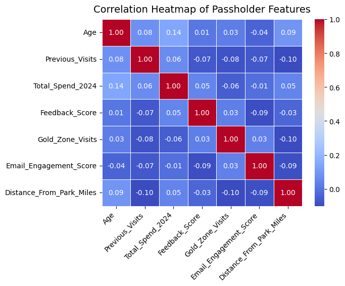

G.

For any variables that need to be dummified, dummify them, being sure to drop one level as you do.

```
passholders.columns
```

```
Index(['Age', 'Previous_Visits', 'Total_Spend_2024', 'Feedback_Score',
       'Gold_Zone_Visits', 'Email_Engagement_Score',
       'Distance_From_Park_Miles', 'Home_State', 'Preferred_Attraction',
       'Referral_Source', 'Dining_Plan', 'Renewed_Pass'],
      dtype='object')
```

```
passholders_new = pd.get_dummies(passholders, columns = ['Home_State', 'Preferred_Attraction',
       'Referral_Source', 'Dining_Plan'], drop_first=True)
passholders_new.head()
```

|  | Age | Previous_Visits | Total_Spend_2024 | Feedback_Score | Gold_Zone_Visits | Email_Engagement_Score | Distance_From_Park_Miles | Renewed_Pass | Home_State_ME | Home_State_NH | Home_State_NJ | Home_State_NY | Home_State_VT | Preferred_Attraction_Other | Preferred_Attraction_Thrill | Referral_Source_Friend | Referral_Source_Social Media | Dining_Plan_Upgraded |
| --- | --- | --- | --- | --- | --- | --- | --- | --- | --- | --- | --- | --- | --- | --- | --- | --- | --- | --- |
| 0 | 59.000000 | 3.000000 | 394.780000 | 4.606232 | 4.000000 | 44.200000 | 1.900000 | 0 | False | False | False | False | True | False | True | False | True | True |
| 1 | 27.846318 | 1.064843 | 172.541334 | 2.102264 | 2.000819 | 37.103840 | 21.709631 | 1 | False | True | False | False | False | True | False | False | False | False |
| 2 | 18.000000 | 5.926144 | 151.731274 | 3.365074 | 1.019084 | 61.827722 | 21.892411 | 1 | False | False | False | False | True | False | False | False | True | True |
| 3 | 25.000000 | 12.000000 | 251.300000 | 3.458663 | 1.000000 | 41.800000 | 6.600000 | 0 | False | False | False | True | False | True | False | True | False | True |
| 4 | 66.206178 | 4.038141 | 197.686695 | 2.985864 | 3.955755 | 61.174332 | 29.981959 | 1 | False | False | True | False | False | False | False | False | False | True |

H.

Create a data partition. For your random_state value, use a number based on either your work, home, or school address, or just a number that you like (For example, I live at 201 Canal Street, I work at 1010 Commonwealth Avenue, and my lucky number is 80, so I could use either 201, 1010, or 80). Assign 40% of your rows to your test set, and 60% to your training set.

a. How did you pick your seed value?

- We had a similar task for an assignemnt in AD699 and I was instructed to use the last 3 digits of my BU ID for my seed value so I've stuck with it!

```
passholders_new.columns
```

```
Index(['Age', 'Previous_Visits', 'Total_Spend_2024', 'Feedback_Score',
       'Gold_Zone_Visits', 'Email_Engagement_Score',
       'Distance_From_Park_Miles', 'Renewed_Pass', 'Home_State_ME',
       'Home_State_NH', 'Home_State_NJ', 'Home_State_NY', 'Home_State_VT',
       'Preferred_Attraction_Other', 'Preferred_Attraction_Thrill',
       'Referral_Source_Friend', 'Referral_Source_Social Media',
       'Dining_Plan_Upgraded'],
      dtype='object')
```

```
X = passholders_new[['Age', 'Previous_Visits', 'Total_Spend_2024', 'Feedback_Score',
       'Gold_Zone_Visits', 'Email_Engagement_Score',
       'Distance_From_Park_Miles', 'Home_State_ME',
       'Home_State_NH', 'Home_State_NJ', 'Home_State_NY', 'Home_State_VT',
       'Preferred_Attraction_Other', 'Preferred_Attraction_Thrill',
       'Referral_Source_Friend', 'Referral_Source_Social Media',
       'Dining_Plan_Upgraded']]

y = passholders_new['Renewed_Pass']
```

```
X_train, X_test, y_train, y_test = train_test_split(X, y, test_size=0.4, random_state= 789)
```

I.

Compare the mean values of the variables in the dataset after grouping by Renewed_Pass.

a. From the results you see here, choose any THREE independent variables from the dataset, and speculate about their likely impact on the result – do you think this variable will be strongly impactful? Why or why not? (This is not a formal statistical test - the goal here is to look at your results and start to speculate about variables that might be impactful).

- Total_Spend_2024 - I do think park visitors total spend will be impactful. Those who did not renew their season pass had an average total spend of 216.40 whilst those who did renew had a spend of just 207.81. Given our dataset is small (1000), a 10 dollar swing is still meaningful. It does make sense however that non renewers would spend slightly more if they are intending on not to return to the park in the following year as they will not get an opportunity in the future.
- Age - The average age of renewing passholders was 44.81, compared to 47.26 for non-renewers. Age is likely an influential factor — older visitors may be less inclined to visit theme parks frequently or maintain an annual pass, while younger guests may have higher interest in repeated experiences.
- Home_State_VT - This was one of the dummified variables, so the 0.29 representing those who did not renew their pass is a proportion of the 241 passholders from VT, and the 420 passholders who did not renew. VT accounts for a large share of total passholders, so an 8% higher proportion of non-renewers is notable and maybe something Lobster Land can look at to try and entice passholders from VT to renew in the future.

```
group_means = passholders_new.groupby('Renewed_Pass').mean(numeric_only=True)
print(group_means.round(2))
```

```
                Age  Previous_Visits  Total_Spend_2024  Feedback_Score  \
Renewed_Pass
0             47.26             4.66            216.40            3.18
1             44.81             4.80            207.81            3.27

              Gold_Zone_Visits  Email_Engagement_Score  \
Renewed_Pass
0                         2.01                   51.26
1                         2.07                   49.00

              Distance_From_Park_Miles  Home_State_ME  Home_State_NH  \
Renewed_Pass
0                                30.24           0.12           0.13
1                                31.05           0.17           0.17

              Home_State_NJ  Home_State_NY  Home_State_VT  \
Renewed_Pass
0                      0.17           0.20           0.29
1                      0.12           0.18           0.21

              Preferred_Attraction_Other  Preferred_Attraction_Thrill  \
Renewed_Pass
0                                   0.45                         0.35
1                                   0.48                         0.32

              Referral_Source_Friend  Referral_Source_Social Media  \
Renewed_Pass
0                               0.19                          0.21
1                               0.14                          0.22

              Dining_Plan_Upgraded
Renewed_Pass
0                             0.64
1                             0.68
```

```
passholders_new['Home_State_VT'].value_counts()
```

| Home_State_VT | count |
| --- | --- |
| False | 759 |
| True | 241 |

**dtype:** int64

```
passholders_new['Renewed_Pass'].value_counts()
```

| Renewed_Pass | count |
| --- | --- |
| 1 | 580 |
| 0 | 420 |

**dtype:** int64

```
passholders['Home_State'].value_counts()
```

| Home_State | count |
| --- | --- |
| VT | 241 |
| NY | 187 |
| NH | 152 |
| ME | 145 |
| NJ | 142 |
| MA | 133 |

**dtype:** int64

**Iteration #1**

J.

Build a logistic regression model using statsmodels, with the outcome variable ‘Renewed_Pass’. Use the rest of the remaining variables from the dataset as inputs. Remember to use only your training data to build this model.

```
import statsmodels.api as sm
from sklearn.metrics import classification_report
```

```
bool_cols = X_train.select_dtypes(include='bool').columns
X_train[bool_cols] = X_train[bool_cols].astype(int)
X_test[bool_cols]  = X_test[bool_cols].astype(int)
```

```
logit_model = sm.Logit(y_train, sm.add_constant(X_train))
```

K.

Show the summary of your model with log_reg.summary(). (Note: If you named your model something else, e.g. mymodel, you can just use mymodel.summary() here).

a. Which of your numeric variables here are showing high p-values?

- Taking an alpha thereshold of 0.1>, Total_Spend_2024, Feedback_Score, Gold_Zone_Visits, Email_Engagement_Score & Distance_From_Park_Miles all have high p-values.

b. For your categorical variables, which ones are showing high p-values for ALL of the levels in the model summary?

- Preffered_Attraction & Dining_Plan.

```
result = logit_model.fit()
print(result.summary())
```

```
Optimization terminated successfully.
         Current function value: 0.642132
         Iterations 5
                           Logit Regression Results
==============================================================================
Dep. Variable:           Renewed_Pass   No. Observations:                  600
Model:                          Logit   Df Residuals:                      582
Method:                           MLE   Df Model:                           17
Date:                Fri, 07 Nov 2025   Pseudo R-squ.:                 0.04588
Time:                        16:10:21   Log-Likelihood:                -385.28
converged:                       True   LL-Null:                       -403.81
Covariance Type:            nonrobust   LLR p-value:                  0.003308
================================================================================================
                                   coef    std err          z      P>|z|      [0.025      0.975]
------------------------------------------------------------------------------------------------
const                            0.8467      0.674      1.256      0.209      -0.475       2.168
Age                             -0.0102      0.006     -1.825      0.068      -0.021       0.001
Previous_Visits                  0.0708      0.039      1.796      0.073      -0.006       0.148
Total_Spend_2024                -0.0012      0.001     -1.470      0.142      -0.003       0.000
Feedback_Score                   0.0490      0.091      0.540      0.589      -0.129       0.227
Gold_Zone_Visits                 0.0660      0.063      1.049      0.294      -0.057       0.189
Email_Engagement_Score          -0.0013      0.005     -0.292      0.770      -0.010       0.008
Distance_From_Park_Miles         0.0040      0.005      0.756      0.450      -0.006       0.014
Home_State_ME                   -0.2254      0.355     -0.634      0.526      -0.922       0.471
Home_State_NH                   -0.1947      0.349     -0.557      0.577      -0.879       0.490
Home_State_NJ                   -0.6738      0.338     -1.996      0.046      -1.335      -0.012
Home_State_NY                   -0.6023      0.321     -1.878      0.060      -1.231       0.026
Home_State_VT                   -0.9746      0.302     -3.223      0.001      -1.567      -0.382
Preferred_Attraction_Other       0.2547      0.236      1.079      0.281      -0.208       0.717
Preferred_Attraction_Thrill     -0.1609      0.254     -0.633      0.527      -0.659       0.337
Referral_Source_Friend          -0.6659      0.269     -2.472      0.013      -1.194      -0.138
Referral_Source_Social Media     0.0751      0.237      0.317      0.751      -0.390       0.540
Dining_Plan_Upgraded             0.1832      0.188      0.973      0.330      -0.186       0.552
================================================================================================
```

**Iteration #2**

L.

Now, build yet another model. Again use statsmodels, and again, use your training set only. Start with the variables you used in Iteration #1 but drop the ones you identified in the previous step, for parts (a) and (b).

a. Show the results of this 2nd model with log_reg.summary().

```
X_train.columns
```

```
Index(['Age', 'Previous_Visits', 'Total_Spend_2024', 'Feedback_Score',
       'Gold_Zone_Visits', 'Email_Engagement_Score',
       'Distance_From_Park_Miles', 'Home_State_ME', 'Home_State_NH',
       'Home_State_NJ', 'Home_State_NY', 'Home_State_VT',
       'Preferred_Attraction_Other', 'Preferred_Attraction_Thrill',
       'Referral_Source_Friend', 'Referral_Source_Social Media',
       'Dining_Plan_Upgraded'],
      dtype='object')
```

```
X_train_2 = X_train[['Age','Previous_Visits', 'Home_State_ME', 'Home_State_NH',
       'Home_State_NJ', 'Home_State_NY', 'Home_State_VT', 'Referral_Source_Friend', 'Referral_Source_Social Media' ]]
```

```
X_test_2 = X_test[['Age','Previous_Visits', 'Home_State_ME', 'Home_State_NH',
       'Home_State_NJ', 'Home_State_NY', 'Home_State_VT', 'Referral_Source_Friend', 'Referral_Source_Social Media' ]]
```

```
logit_model_2 = sm.Logit(y_train, sm.add_constant(X_train_2))
```

```
result_2 = logit_model_2.fit()
print(result_2.summary())
```

```
Optimization terminated successfully.
         Current function value: 0.649704
         Iterations 5
                           Logit Regression Results
==============================================================================
Dep. Variable:           Renewed_Pass   No. Observations:                  600
Model:                          Logit   Df Residuals:                      590
Method:                           MLE   Df Model:                            9
Date:                Fri, 07 Nov 2025   Pseudo R-squ.:                 0.03463
Time:                        16:10:21   Log-Likelihood:                -389.82
converged:                       True   LL-Null:                       -403.81
Covariance Type:            nonrobust   LLR p-value:                 0.0009651
================================================================================================
                                   coef    std err          z      P>|z|      [0.025      0.975]
------------------------------------------------------------------------------------------------
const                            1.1302      0.409      2.763      0.006       0.329       1.932
Age                             -0.0101      0.005     -1.856      0.063      -0.021       0.001
Previous_Visits                  0.0669      0.039      1.737      0.082      -0.009       0.142
Home_State_ME                   -0.1818      0.343     -0.530      0.596      -0.853       0.490
Home_State_NH                   -0.1111      0.336     -0.331      0.741      -0.770       0.548
Home_State_NJ                   -0.6515      0.330     -1.972      0.049      -1.299      -0.004
Home_State_NY                   -0.6102      0.311     -1.963      0.050      -1.220      -0.001
Home_State_VT                   -0.9234      0.294     -3.139      0.002      -1.500      -0.347
Referral_Source_Friend          -0.6130      0.262     -2.336      0.019      -1.127      -0.099
Referral_Source_Social Media    -0.0390      0.224     -0.174      0.862      -0.478       0.400
================================================================================================
```

M.

Using scikit-learn, build another version of your model, using your remaining variables. You will use this version of the model for all remaining steps.

```
logmodel = LogisticRegression(max_iter=1000)
logmodel.fit(X_train_2, y_train)
```

```
LogisticRegression(max_iter=1000)
```

N.

Assess the performance of your model against the test set. Build a confusion matrix, and answer the following questions about your model. You can use Python functions to answer any of these questions or you can use your confusion matrix to determine the answers in a slightly more manual way. The ‘positive’ class in this model is represented by the “1” outcome.

a. What is your model’s accuracy rate?

b. What is your model’s sensitivity rate?

c. What is your model’s specificity rate?

d. What is your model’s precision?

e. What is your model’s balanced accuracy?

```
predictions1 = logmodel.predict(X_train_2)
accuracy_score(y_train, predictions1)
```

```
0.6166666666666667
```

```
predictions2 = logmodel.predict(X_test_2)
accuracy_score(y_test, predictions2)
```

```
0.5625
```

```
matrix_1 = confusion_matrix(predictions2, y_test)
```

```
conf_matrix = sns.heatmap(matrix_1, square = True, fmt = 'g', annot = True, cbar = False, cmap = 'Greens')
plt.xlabel('Predicted Values')
plt.ylabel('Actual Values')
plt.title('Confusion Matrix')
a,b = plt.ylim()
a+=0.5
b-=0.5
plt.ylim(a,b)
plt.show()
```

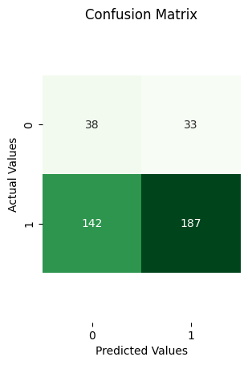

```
total_matrix_1 = sum(sum(matrix_1))
total_matrix_1
```

```
np.int64(400)
```

```
accuracy_matrix_1 = (matrix_1[0,0] + matrix_1[1,1]) / total_matrix_1
print('Accuracy for Matrix 1:',accuracy_matrix_1)
```

```
Accuracy for Matrix 1: 0.5625
```

```
sensitivity_matrix_1 = matrix_1[1,1] / (matrix_1[1,0] + matrix_1[1,1])
print('Sensitivity for Matrix 1:', sensitivity_matrix_1)
```

```
Sensitivity for Matrix 1: 0.5683890577507599
```

[output not shown]

[output not shown]

```
precision_matrix_1 = matrix_1[1,1] / (matrix_1[0,1] +matrix_1[1,1])
print('Precision for Matrix 1:', precision_matrix_1)
```

```
Precision for Matrix 1: 0.85
```

```
balanced_accuracy_matrix_1 = (sensitivity_matrix_1 + specificity_matrix_1) / 2
print('Balanced Accuracy for Matrix 1:', balanced_accuracy_matrix_1)
```

```
Balanced Accuracy for Matrix 1: 0.5518001626781968
```

O.

What is the naive accuracy rate (baseline rate) for this dataset? How does this compare with your model’s accuracy rate? If a classification model’s accuracy is not much better than the naive rate, can the model still be useful? If so, how?

- Naive accuracy rate: 0.55
- The classification model’s accuracy rate was 0.0125 (1.25 percentage points) higher than the naïve baseline accuracy. While the overall accuracy of 0.5625 (56.25%) appears low, the model still remains extremely useful. Even a small improvement over the baseline can translate into significant business value when applied at scale. This can have a large financial impact for companies managing thousands or millions of customers, when compared against our small dataset.

```
naive_rate = y_test.value_counts(normalize=True)
print(naive_rate)
```

```
Renewed_Pass
1    0.55
0    0.45
Name: proportion, dtype: float64
```

P.

Compare your model’s accuracy against the training set vs. accuracy against the test set (just use accuracy only for this).

a. What is the purpose of comparing those two values?

- The training accuracy will show us how well the model learned the patterns in the data in saw. Whilst the test accuracy will show us how well the model works when shown new, unseen data.

b. In this case, what does the comparison of those values suggest about the model that you have built?

- Looking at our two values from our training set (0.6167) and test set (0.5625), we can observe that the model performs slightly better on training data than unseen data. Although the model performs better on the training data the difference is marginal, therefore there is no major evidence of overfitting. There is some evidence of underfitting however as both models accuracies are low, additional or more informative features should be added to improve accuracy.

Q.

Make up a passholder. Assign this customer a value for each predictor variable in this model, and store the results in a new dataframe. Now, put your passholder through this model.

a. What did your model predict -- will this passholder renew?

- Dave unfortunately will not renew.

b. According to your model, what is the probability that the passholder will renew?

- 0.4985! We just missed out on Dave renewing his pass for the next season. For LobsterLand, they should concentrate their marketing efforts on customers like Dave who are hovering around that 50/50 mark to ensure that he and others alike renew their passes for the upcoming season.

```
X_train_2.columns
```

```
Index(['Age', 'Previous_Visits', 'Home_State_ME', 'Home_State_NH',
       'Home_State_NJ', 'Home_State_NY', 'Home_State_VT',
       'Referral_Source_Friend', 'Referral_Source_Social Media'],
      dtype='object')
```

```
Dave = {'Age': 46, 'Previous_Visits' : 4, 'Home_State_ME': 0, 'Home_State_NH': 0,
       'Home_State_NJ': 0, 'Home_State_NY': 0, 'Home_State_VT' : 1, 'Referral_Source_Friend': 0, 'Referral_Source_Social Media' : 1}
```

```
dave_new = pd.DataFrame(Dave, index=[0])
dave_new
```

|  | Age | Previous_Visits | Home_State_ME | Home_State_NH | Home_State_NJ | Home_State_NY | Home_State_VT | Referral_Source_Friend | Referral_Source_Social Media |
| --- | --- | --- | --- | --- | --- | --- | --- | --- | --- |
| 0 | 46 | 4 | 0 | 0 | 0 | 0 | 1 | 0 | 1 |

```
dave_renew_pred = logmodel.predict(dave_new)[0]
print("Will Dave renew his pass?:", "Yes" if dave_renew_pred == 1 else "No")
```

```
Will Dave renew his pass?: No
```

```
dave_prob = logmodel.predict_proba(dave_new)[0][1]
print("Probability of Dave renewing his pass:",round(dave_prob,4))
```

```
Probability of Dave renewing his pass: 0.4985
```

R.

When using a logistic regression model to make predictions, why is it important to only use values within the range of the dataset used to build the model?

- When the modeler tries to predict an outcome value using input variables outside the range of the dataset, this is referred to as extrapolation. The model only knows the relationships between the inputs and the outcome for the data that is sees during model fitting. The nature of that relationship may change at other ranges of values, so any model prediction based on extrapolated inputs would not be reliable.

a. Make a new dataframe, but this time, for the numeric predictor variables, select some numbers that are outside the range of the dataset -- do not use a 400+ year-old vampire named “Mary.” Use your model to make a prediction for this new dataframe. What do you notice about the result? (To answer this, don’t simply state the predicted outcome, but also write 1-2 sentences of explanation for what you see).

- Sheila will renew her pass and the probability that she does so is an almost gauranteed 0.8981. The model has been trained on a specific dataframe with a range of values. If we go back and look at the describe output from our original dataset, the min and max values for age was 18 & 74, respectively. Therefore, the model has never encountered an input such as Age = 0.5, but still interprets it as a strongly positive indicator since Age was statistically significant in the training model. The same applies for previous visits, the max previous visits from our original data was 12, so a value of 30 leads the model to overconfidently predict renewal.

```
Sheila = {'Age': 0.5 , 'Previous_Visits' : 30, 'Home_State_ME': 0, 'Home_State_NH': 0,
       'Home_State_NJ': 0, 'Home_State_NY': 0, 'Home_State_VT' : 1, 'Referral_Source_Friend': 0, 'Referral_Source_Social Media' : 1}
```

```
Sheila_new = pd.DataFrame(Sheila, index=[0])
```

```
sheila_renew_pred = logmodel.predict(Sheila_new)[0]
print("Will Sheila renew her pass?:", "Yes" if sheila_renew_pred == 1 else "No")
```

```
Will Sheila renew her pass?: Yes
```

```
sheila_prob = logmodel.predict_proba(Sheila_new)[0][1]
print("Probability of Sheila renewing her pass:",round(sheila_prob,4))
```

```
Probability of Sheila renewing her pass: 0.8981
```

**Part II: Random Forest Model**

S.

Read the dataset back into Python. For the steps you took in the previous section with regards to missingness and impossible values, repeat those here.

```
passholders_2 = pd.read_csv('lobsterland_passholders_dataset_25.csv')
passholders_2.head()
```

|  | Age | Previous_Visits | Total_Spend_2024 | Feedback_Score | Gold_Zone_Visits | Email_Engagement_Score | Distance_From_Park_Miles | Home_State | Preferred_Attraction | Referral_Source | Dining_Plan | Renewed_Pass |
| --- | --- | --- | --- | --- | --- | --- | --- | --- | --- | --- | --- | --- |
| 0 | 59.000000 | 3.000000 | 394.780000 | 4.606232 | 4.000000 | 44.200000 | 1.900000 | VT | Thrill | Social Media | Upgraded | 0 |
| 1 | 27.846318 | 1.064843 | 172.541334 | 2.102264 | 2.000819 | 37.103840 | 21.709631 | NH | Other | Ad/Other | NaN | 1 |
| 2 | 18.000000 | 5.926144 | 151.731274 | 3.365074 | 1.019084 | 61.827722 | 21.892411 | VT | Entertainment | Social Media | Upgraded | 1 |
| 3 | 25.000000 | 12.000000 | 251.300000 | 3.458663 | 1.000000 | 41.800000 | 6.600000 | NY | Other | Friend | Upgraded | 0 |
| 4 | 66.206178 | 4.038141 | 197.686695 | 2.985864 | 3.955755 | 61.174332 | 29.981959 | NJ | Entertainment | Ad/Other | Upgraded | 1 |

```
passholders_2['Dining_Plan'] = passholders_2['Dining_Plan'].fillna('None')
passholders_2['Dining_Plan'].value_counts()
```

| Dining_Plan | count |
| --- | --- |
| Upgraded | 667 |
| None | 333 |

**dtype:** int64

```
passholders_2['Email_Engagement_Score'] = passholders_2['Email_Engagement_Score'].mask(
    (passholders_2['Email_Engagement_Score'] < 0) | (passholders_2['Email_Engagement_Score'] > 100),
    passholders_2['Email_Engagement_Score'].median()
)
```

T.

Dummify the categorical inputs again, but this time, don’t drop any levels.

```
passholders_2_new = pd.get_dummies(passholders_2, columns = ['Home_State', 'Preferred_Attraction',
       'Referral_Source', 'Dining_Plan'])
passholders_2_new.head()
```

|  | Age | Previous_Visits | Total_Spend_2024 | Feedback_Score | Gold_Zone_Visits | Email_Engagement_Score | Distance_From_Park_Miles | Renewed_Pass | Home_State_MA | Home_State_ME | ... | Home_State_NY | Home_State_VT | Preferred_Attraction_Entertainment | Preferred_Attraction_Other | Preferred_Attraction_Thrill | Referral_Source_Ad/Other | Referral_Source_Friend | Referral_Source_Social Media | Dining_Plan_None | Dining_Plan_Upgraded |
| --- | --- | --- | --- | --- | --- | --- | --- | --- | --- | --- | --- | --- | --- | --- | --- | --- | --- | --- | --- | --- | --- |
| 0 | 59.000000 | 3.000000 | 394.780000 | 4.606232 | 4.000000 | 44.200000 | 1.900000 | 0 | False | False | ... | False | True | False | False | True | False | False | True | False | True |
| 1 | 27.846318 | 1.064843 | 172.541334 | 2.102264 | 2.000819 | 37.103840 | 21.709631 | 1 | False | False | ... | False | False | False | True | False | True | False | False | True | False |
| 2 | 18.000000 | 5.926144 | 151.731274 | 3.365074 | 1.019084 | 61.827722 | 21.892411 | 1 | False | False | ... | False | True | True | False | False | False | False | True | False | True |
| 3 | 25.000000 | 12.000000 | 251.300000 | 3.458663 | 1.000000 | 41.800000 | 6.600000 | 0 | False | False | ... | True | False | False | True | False | False | True | False | False | True |
| 4 | 66.206178 | 4.038141 | 197.686695 | 2.985864 | 3.955755 | 61.174332 | 29.981959 | 1 | False | False | ... | False | False | True | False | False | True | False | False | False | True |

5 rows × 22 columns

U.

Re-partition the data, using the same seed value that you used in the previous part of this assignment.

```
passholders_2_new.columns
```

```
Index(['Age', 'Previous_Visits', 'Total_Spend_2024', 'Feedback_Score',
       'Gold_Zone_Visits', 'Email_Engagement_Score',
       'Distance_From_Park_Miles', 'Renewed_Pass', 'Home_State_MA',
       'Home_State_ME', 'Home_State_NH', 'Home_State_NJ', 'Home_State_NY',
       'Home_State_VT', 'Preferred_Attraction_Entertainment',
       'Preferred_Attraction_Other', 'Preferred_Attraction_Thrill',
       'Referral_Source_Ad/Other', 'Referral_Source_Friend',
       'Referral_Source_Social Media', 'Dining_Plan_None',
       'Dining_Plan_Upgraded'],
      dtype='object')
```

```
X_2 = passholders_2_new[['Age', 'Previous_Visits', 'Total_Spend_2024', 'Feedback_Score',
       'Gold_Zone_Visits', 'Email_Engagement_Score',
       'Distance_From_Park_Miles', 'Home_State_MA',
       'Home_State_ME', 'Home_State_NH', 'Home_State_NJ', 'Home_State_NY',
       'Home_State_VT', 'Preferred_Attraction_Entertainment',
       'Preferred_Attraction_Other', 'Preferred_Attraction_Thrill',
       'Referral_Source_Ad/Other', 'Referral_Source_Friend',
       'Referral_Source_Social Media', 'Dining_Plan_None',
       'Dining_Plan_Upgraded']]
```

```
y_2 = passholders_2_new['Renewed_Pass']
```

```
X2_train, X2_test, y2_train, y2_test = train_test_split(X_2, y_2, test_size=0.4, random_state= 789)
```

V.

Build a random forest model in Python with your training set. Use the same input variables, and same output variable, as you used in the first logistic regression model (the only difference here is that the categories should not have any levels dropped).

Use GridSearchCV to help you determine the best hyperparameter settings for your model.

```
from sklearn.ensemble import RandomForestClassifier
clf=RandomForestClassifier()
clf.fit(X2_train, y2_train)
```

```
RandomForestClassifier()
```

```
param_grid = {
    'n_estimators': [200, 400, 600],
    'max_depth': [4, 8, 12, 16],
    'max_features': ['sqrt', 'log2', 0.5],
    'min_samples_leaf': [6,8,10],
}
```

```
from sklearn.model_selection import GridSearchCV

CV_rfc = GridSearchCV(estimator=clf, param_grid=param_grid, cv= 5)
CV_rfc.fit(X2_train, y2_train)
print(CV_rfc.best_params_)
```

```
{'max_depth': 8, 'max_features': 'log2', 'min_samples_leaf': 10, 'n_estimators': 200}
```

```
clf = RandomForestClassifier(n_estimators=200, max_depth=8, max_features='log2', min_samples_leaf=10, random_state=789, n_jobs=-1)
clf.fit(X2_train, y2_train)
```

```
RandomForestClassifier(max_depth=8, max_features='log2', min_samples_leaf=10,
                       n_estimators=200, n_jobs=-1, random_state=789)
```

W.

How did your random forest model rank the variables in order of importance, from highest to lowest? For a random forest model, how can you interpret feature importance?

- The Random Forest model ranked Distance_From_Park_Miles, Feedback_Score, and Total_Spend_2024 as the three most important predictors of whether a passholder would renew, followed closely by Age, Email_Engagement_Score, and Previous_Visits.The 3 lowest predictors were Home_State_NJ, Referral_Source_Social Media and Home_State_ME.
- The higher that some variable appears in this feature importance table, the more effective it was at separating the records into distinct groups throughout the entire ensemble. Variables here are ranked by their overall contribution to Gini impurity reduction.

```
feature_imp_df = pd.DataFrame(list(zip(clf.feature_importances_, X2_train)))
feature_imp_df.columns = ['Feature Importance', 'Feature']
feature_imp_df = feature_imp_df.sort_values(by='Feature Importance', ascending=False)
feature_imp_df
```

|  | Feature Importance | Feature |
| --- | --- | --- |
| 6 | 0.131015 | Distance_From_Park_Miles |
| 3 | 0.125620 | Feedback_Score |
| 2 | 0.123528 | Total_Spend_2024 |
| 0 | 0.123146 | Age |
| 5 | 0.109121 | Email_Engagement_Score |
| 1 | 0.104030 | Previous_Visits |
| 4 | 0.077718 | Gold_Zone_Visits |
| 12 | 0.035735 | Home_State_VT |
| 17 | 0.022141 | Referral_Source_Friend |
| 14 | 0.022116 | Preferred_Attraction_Other |
| 15 | 0.016000 | Preferred_Attraction_Thrill |
| 20 | 0.015508 | Dining_Plan_Upgraded |
| 16 | 0.014969 | Referral_Source_Ad/Other |
| 9 | 0.013829 | Home_State_NH |
| 19 | 0.012122 | Dining_Plan_None |
| 7 | 0.012071 | Home_State_MA |
| 13 | 0.011441 | Preferred_Attraction_Entertainment |
| 11 | 0.008925 | Home_State_NY |
| 10 | 0.008227 | Home_State_NJ |
| 18 | 0.008150 | Referral_Source_Social Media |
| 8 | 0.004587 | Home_State_ME |

X.

Assess the performance of your model against the test set. Build a confusion matrix to do this. You can use Python functions to answer any of these questions or you can use your confusion matrix to determine the answers in a slightly more manual way. The ‘positive’ class in this model is represented by the “1” outcome.

a. What is your model’s accuracy rate?

b. What is your model’s sensitivity rate?

c. What is your model’s specificity rate?

d. What is your model’s precision?

e. What is your model’s balanced accuracy?

```
from sklearn import metrics
predictions_1 = clf.predict(X2_test)
print("Accuracy:",metrics.accuracy_score(y2_test, predictions_1))
```

```
Accuracy: 0.56
```

```
matrix_2 = confusion_matrix(predictions_1, y2_test)
```

```
conf_matrix_2 = sns.heatmap(matrix_2, square = True, fmt = 'g', annot = True, cbar = False, cmap = 'Blues')
plt.xlabel('Predicted Values')
plt.ylabel('Actual Values')
plt.title('Confusion Matrix')
a,b = plt.ylim()
a+=0.5
b-=0.5
plt.ylim(a,b)
plt.show()
```

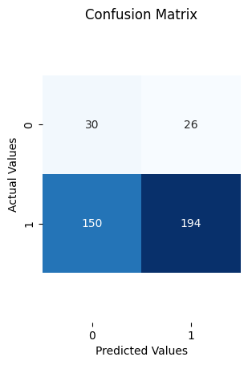

```
from sklearn.metrics import (
    accuracy_score, recall_score, precision_score)
```

```
accuracy = accuracy_score(y2_test, predictions_1)
print('Accuracy for Matrix 2:',accuracy)
```

```
Accuracy for Matrix 2: 0.56
```

```
sensitivity = recall_score(y2_test, predictions_1)
print('Sensitivity for Matrix 2:', sensitivity)
```

```
Sensitivity for Matrix 2: 0.8818181818181818
```

```
specificity = matrix_2[0,0] / (matrix_2[0,0] + matrix_2[0,1])
print('Specificity for Matrix 2:', specificity)
```

```
Specificity for Matrix 2: 0.5357142857142857
```

```
precision = precision_score(y2_test, predictions_1)
print('Precision for Matrix 2:', precision)
```

```
Precision for Matrix 2: 0.563953488372093
```

```
balanced_accuracy = (sensitivity + specificity) / 2
print('Balanced Accuracy for Matrix 2:', balanced_accuracy)
```

```
Balanced Accuracy for Matrix 2: 0.7087662337662337
```

Y.

Compare your model’s accuracy against the training set vs. your model’s accuracy against the test set. How different were these results?

- The Random Forest model achieved a training accuracy of 0.72 and a test accuracy of 0.56, showing a noticeable difference between the two. This gap suggests that the model may be overfitting the training data, performing well on the data it was trained on but less effectively on unseen data

```
predictions_2 = clf.predict(X2_train)
print("Training accuracy:",metrics.accuracy_score(y2_train, predictions_2))
```

```
Training accuracy: 0.7216666666666667
```

Z.

Use the predict() function with your model to classify the person who you invented in the previous section. Does the model think that the passholder will renew?

(Note: This question says to “classify the person.” It does not say that the dataframe will be set up in the exact same way).

- Dave 2.0's predicted probability that he will renew his pass this time around is 0.6268. Since this probability is above the 0.5 threshold used for classification, the model interprets Dave’s profile as more likely than not to renew.

```
X2_train.columns
```

```
Index(['Age', 'Previous_Visits', 'Total_Spend_2024', 'Feedback_Score',
       'Gold_Zone_Visits', 'Email_Engagement_Score',
       'Distance_From_Park_Miles', 'Home_State_MA', 'Home_State_ME',
       'Home_State_NH', 'Home_State_NJ', 'Home_State_NY', 'Home_State_VT',
       'Preferred_Attraction_Entertainment', 'Preferred_Attraction_Other',
       'Preferred_Attraction_Thrill', 'Referral_Source_Ad/Other',
       'Referral_Source_Friend', 'Referral_Source_Social Media',
       'Dining_Plan_None', 'Dining_Plan_Upgraded'],
      dtype='object')
```

```
Dave_2_new = {'Age': 46, 'Previous_Visits': 6, 'Total_Spend_2024': 210, 'Feedback_Score': 3.8,
       'Gold_Zone_Visits': 3, 'Email_Engagement_Score': 48.76,
       'Distance_From_Park_Miles': 33, 'Home_State_MA': 0 , 'Home_State_ME': 0,
       'Home_State_NH': 0, 'Home_State_NJ': 0, 'Home_State_NY': 0, 'Home_State_VT': 1,
       'Preferred_Attraction_Entertainment':1, 'Preferred_Attraction_Other': 0,
       'Preferred_Attraction_Thrill': 0, 'Referral_Source_Ad/Other': 0,
       'Referral_Source_Friend': 0, 'Referral_Source_Social Media': 1,
       'Dining_Plan_None': 1, 'Dining_Plan_Upgraded': 0}
```

```
davey_2_new = pd.DataFrame([Dave_2_new])
```

```
davey_2_new = davey_2_new.reindex(columns=X2_train.columns, fill_value=0)
davey_2_new = davey_2_new.apply(pd.to_numeric, errors='raise')
```

```
davey_2_pred = clf.predict(davey_2_new)[0]
print("Will new Dave renew his pass?:", "Yes" if davey_2_pred == 1 else "No")
```

```
Will new Dave renew his pass?: Yes
```

```
davey_2_prob = clf.predict_proba(davey_2_new)[0][1]
print("Probability of Dave renewing his pass:",round(davey_2_prob,4))
```

```
Probability of Dave renewing his pass: 0.6268
```

AA.

Write a 3-5 sentence paragraph that speculates about how Lobster Land might be able to use the results that you’ve obtained from these models (LR and/or RF) for a practical purpose.

Lobster Land could use the insights from both the Logistic Regression and Random Forest models to better target and retain its season passholders. By identifying which variables most strongly influence renewal decisions such as visitor age, previous visits, and email engagement, the park can tailor marketing campaigns and loyalty incentives toward customers most likely to renew. By calling the predict proba function, they can identify which customers renewal probabilities are hovering around the 50/50 mark, such as Dave from earlier. By doing this they can then target these customers with promotions to try and sway them in the right direction. This also allows them to identify which customers are defintely going to renew, and those who defintely aren't (according to the model) so that they don't waste resources targeting these passholders.

**Part III: Using Tableau to Build a Dashboard**

```
from PIL import Image
import matplotlib.pyplot as plt

image = Image.open('Dashboard.png')

plt.figure(figsize=(10, 8))
plt.imshow(image)
plt.axis('off')
plt.title('Tablaeu Dashboard')
plt.show()
```

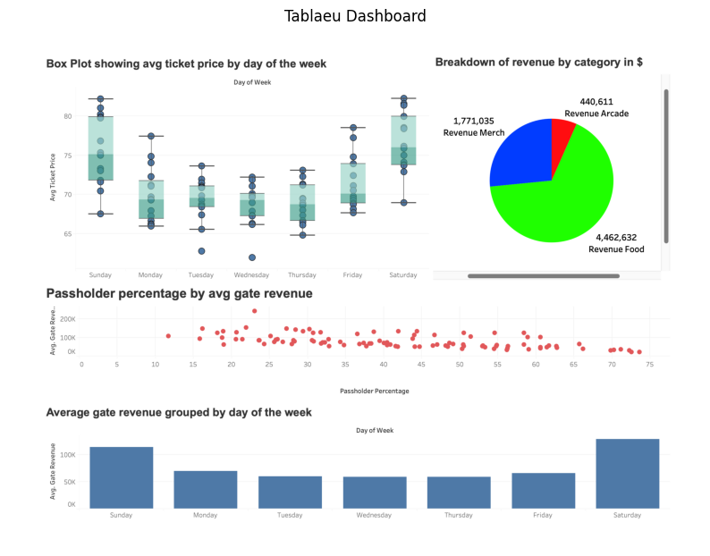

This dashboard provides an overview of Lobster Land’s key park performance metrics using a mix of visualizations to highlight visitor behavior and revenue patterns. The box plot in the top left shows how average ticket prices fluctuate across the week, with noticeably higher prices on weekends, particularly Sunday and Saturday, we also found that Monday's prices appear to be slightly higher than those from Tuesday - Thursday, likely due to bank holiday's falling on Mondays. The pie chart breaks down total park revenue by category, revealing that food sales dominate overall income, followed by merchandise and arcade revenue. The scatter plot illustrates (although not very well in rhe dashboard) the relationship between passholder percentage and average gate revenue, showing us that revenue tends to decrease with higher passholder participation which confirms what I explored in a previous assignment. Finally, the bar chart at the bottom displays average gate revenue by day of the week, confirming that weekends drive the highest revenue.

Overall this task proved a little tedious to get the visualizations onto the one dashboard so further training in Tablaeu may be needed!